# Cluster analysis

## Guía para análisis de cluster en R

Joaquín Bahamondes, Ph.D.  
jbahamondes@ucn.cl  
[Google Scholar](https://scholar.google.com/citations?user=YETb1hIAAAAJ&hl=en) | [Researchgate](https://www.researchgate.net/profile/Joaquin-Bahamondes/)  
Septiembre, 2021

El *Cluster analysis*, o análisis de cluster, es una técnica de agrupación para un conjunto de variables, capaz de clasificar sujetos en función de sus respuestas a dichas variables (en tanto atributos comunes).

En esta guía revisaremos las estrategias de estimación de clusters más comunes, a través de un ejemplo y un ejercicio.

En el siguiente ejemplo, utilizamos datos de una base de datos pública (“USArrests”) que contiene información sobre crimen en distintos estados de Estados Unidos.

```r
#Cargar y utilizar función IPAK
#ver vídeo https://www.youtube.com/watch?v=UjQz9SxG9rk

ipak <- function(pkg){
  new.pkg <- pkg[!(pkg %in% installed.packages()[, "Package"])]
  if (length(new.pkg))
    install.packages(new.pkg, dependencies = TRUE)
  sapply(pkg, require, character.only = TRUE)
}

packages <- c("tidyverse","cluster", "factoextra","NbClust","tidyr")
ipak(packages)

#Cargar datos USArrests y asignarles etiqueta corta (df)

df <- USArrests
df
```

Dado que las distintas variables están escaladas de distinta forma, es decir, tienen un mínimo, máximo y rango distinto, las estandarizaremos usando la función `scale()` para reemplazar cada puntaje bruto por desviaciones estándar.

```r
#normalizar las puntuaciones
df <- scale(df)
#revisar si las puntuaciones están normalizadas
head(df)
```

### Estimación de distancias

Para poder clasificar los casos de acuerdo a sus puntajes en *j* variables, necesitamos un indicador de distancia entre casos; Es decir, qué tan lejos está un caso de otro respecto de los puntajes en las variables de interés. Para dicho propósito, la mdedia de distancia más utilizada es la *distancia euclídea*

La distancia euclídea puede ser interpretada como la distancia física entre dos puntos p-dimensionales (casos) en un espacio euclídeo. Estas distancias pueden ser representadas gráficamente en *R* utilizando el siguiente código:

```r
#calcular la matriz de distacias
m.distancia <- get_dist(df, method = "euclidean")

#visualizar la matriz de distancia
fviz_dist(m.distancia, gradient = list(low = "blue", mid = "white", high = "red"))
```

[output not shown]

Si bien una inspección inicial indica que los casos parecen ser clasificables, no sabemos en cuántos grupos debemos agrupar la información. Por lo tanto, lo siguiente es dar respuesta a cuántos grupos resumen adecuadamente esta matriz de distancias.

### Extracción de *k* grupos

```r
#estimar el número de clústers
#Elbow, silhouette o gap_stat  method
fviz_nbclust(df, kmeans, method = "wss")
fviz_nbclust(df, kmeans, method = "silhouette")
fviz_nbclust(df, kmeans, method = "gap_stat")
```

[output not shown]

Podemos ir más allá, y estimar un análisis más robusto para decidir sobre cuántos clusters extraer. Para esto, *R* tiene la capacidad de estimar el resultado de 30 indicadores distintos, para decidir en base a la regla de la mayoría.

```r
#con esta función se pueden calcular:
#the index to be calculated. This should be one of : "kl", "ch", "hartigan", "ccc", "scott",
#"marriot", "trcovw", "tracew", "friedman", "rubin", "cindex", "db", "silhouette", "duda",
#"pseudot2", "beale", "ratkowsky", "ball", "ptbiserial", "gap", "frey", "mcclain", "gamma",
#"gplus", "tau", "dunn", "hubert", "sdindex", "dindex", "sdbw", "all" (all indices except GAP,
#Gamma, Gplus and Tau), "alllong" (all indices with Gap, Gamma, Gplus and Tau included).
resnumclust<-NbClust(df, distance = "euclidean", min.nc=2, max.nc=10, method = "kmeans", index = "alllong")
fviz_nbclust(resnumclust)
```

[output not shown]

### Estimación de clusters k-medias

Utilizamos entonces el cálculo de k-medias (k-means), que a través de un número definido de iteraciones ( establecidas en `nstart =`) estima *k* centros (dos en este caso) que definen ambos clusters, y los casos que pertenecen a cada cual.

Este análisis nos entregará información sobre el tamaño de cada cluster, es decir, el *n* de casos en cada uno de los *k* grupos (clusters). Para este ejemplo, los resultados muestran que hay un cluster compuesto por 30, y otro por 20 estados.

Luego, se observan las medias de cada variable de interés por cluster. De este conjunto de resultados cuantitativos, podemos inferir qué es lo que diferencia cualitativamente a los clusters. En este caso, dadas las medias observadas en el cluster 1y el 2, se puede concluir que el cluster 2 agrupa estados más inseguros que el cluster 1.

Finalmente, la última pieza de información entregada es relativa a la bondad de ajuste, en un indicador de varianza explicada $\frac{between_{SS}}{total_{SS}}$, que en español equivale a $\frac{entre_{SC}}{total_{SC}}$. Basicamente, el resultado es la proporción de variabilidad *entre* clusters relativa a la variabilidad *total* entre los elementos (incluyendo la variabilidad *intra* cluster). Idealmente, lo que buscamos al agrupar es una solución en la que se evidencia coesión interna dentro de los clusters (intra), y separación o diferenciación externa *entre* clusters. Un $\frac{between_{SS}}{total_{SS}} = 1$ indicaría total cohesión intra-cluster y total diferenciación entre-clusters. Dicho de modo más simple, que los grupos son más diferentes entre sí que los elementos que componen cada cluster entre ellos.

```r
#calculamos los dos clústers (y guardamos la información del análisis en un objeto llamado k2)
k2 <- kmeans(df, centers = 2, nstart = 25)
k2
```

[output not shown]

Dado que hemos grabado la información estimada en el análisis como un objeto (`k2`), podemos inspeccionar la información contenida en él.

```r
str(k2)
```

```
List of 9
 $ cluster     : Named int [1:50] 2 2 2 1 2 2 1 1 2 2 ...
  ..- attr(*, "names")= chr [1:50] "Alabama" "Alaska" "Arizona" "Arkansas" ...
 $ centers     : num [1:2, 1:4] -0.67 1.005 -0.676 1.014 -0.132 ...
  ..- attr(*, "dimnames")=List of 2
  .. ..$ : chr [1:2] "1" "2"
  .. ..$ : chr [1:4] "Murder" "Assault" "UrbanPop" "Rape"
 $ totss       : num 196
 $ withinss    : num [1:2] 56.1 46.7
 $ tot.withinss: num 103
 $ betweenss   : num 93.1
 $ size        : int [1:2] 30 20
 $ iter        : int 1
 $ ifault      : int 0
 - attr(*, "class")= chr "kmeans"
```

### Visualización de los clusters

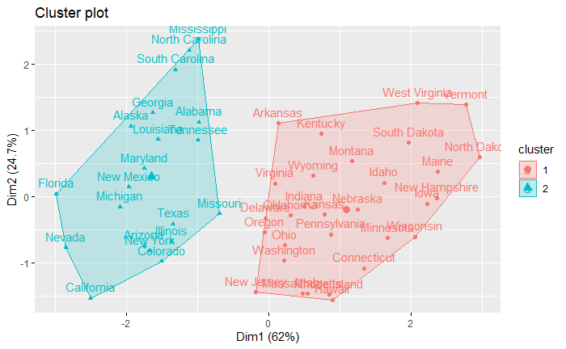

```r
#plotear los cluster
fviz_cluster(k2, data = df)
```

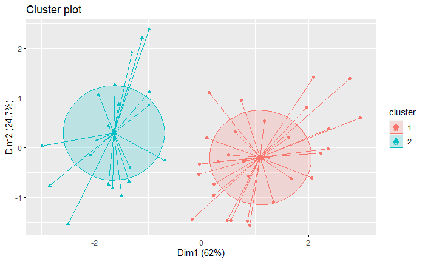

```r
fviz_cluster(k2, data = df, ellipse.type = "euclid",repel = TRUE,star.plot = TRUE) #ellipse.type= "t", "norm", "euclid"
```

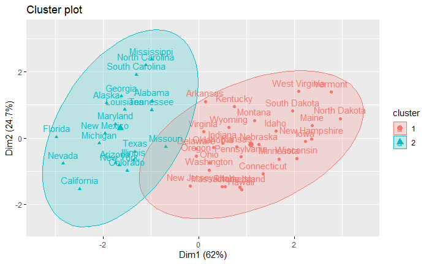

```r
fviz_cluster(k2, data = df, ellipse.type = "norm")
```

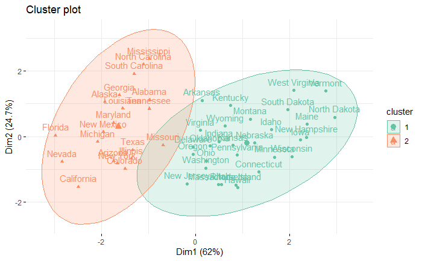

```r
fviz_cluster(k2, data = df, ellipse.type = "norm",palette = "Set2", ggtheme = theme_minimal())
```

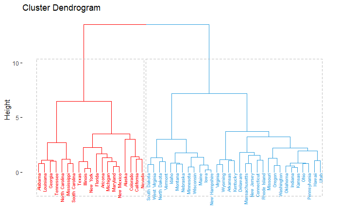

```r
res2 <- hcut(df, k = 2, stand = TRUE)
fviz_dend(res2, rect = TRUE, cex = 0.5,
          k_colors = c("red","#2E9FDF"))
```

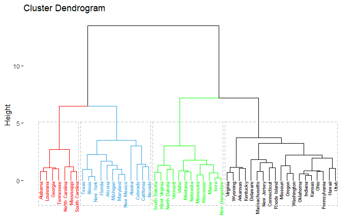

```r
res4 <- hcut(df, k = 4, stand = TRUE)
fviz_dend(res4, rect = TRUE, cex = 0.5,
          k_colors = c("red","#2E9FDF","green","black"))
```

```r
#pasar los cluster a mi df inicial para trabajar con ellos

USArrests %>%
  mutate(Cluster = k2$cluster) %>%
  group_by(Cluster) %>%
  summarise_all("mean")

df <- USArrests
df
df$clus<-as.factor(k2$cluster)
df

df <- USArrests
df <- scale(df)
df<- as.data.frame(df)
df$clus<-as.factor(k2$cluster)
df

df$clus<-factor(df$clus)
data_long <- gather(df, caracteristica, valor, Murder:Rape, factor_key=TRUE)
data_long

ggplot(data_long, aes(as.factor(x = caracteristica), y = valor,group=clus, colour = clus)) +
  stat_summary(fun = mean, geom="pointrange", size = 1)+
  stat_summary(geom="line")
  #geom_point(aes(shape=clus))
```